```python
import numpy as np
from sklearn.datasets import load_iris
from sklearn.neighbors import KNeighborsClassifier
from sklearn.model_selection import train_test_split
import matplotlib.pyplot as plt
import pandas as pd
```

# OOP: A Data Science Perspective

##### Written by Eliot Martin (eliotm@uoregon.edu)

As a data scientist, you will encounter object-oriented programming concepts everywhere. For instance, many popular data science libraries such as Numpy, Scikit-learn, Pandas, and PyTorch rely heavily on object-oriented programming. To use these libraries effectively will require you to understand object-oriented programming.

To understand the importance of object-oriented programming in data science, let's walk through a small data science problem and consider our choices from an OOP perspective.

## The Iris dataset

For our small data science problem, we will use the `iris` dataset, which consists of measurements for the sepal length, sepal width, petal length, and petal width of three species of Iris flowers: Setosa, Versicolor, and Virginica. Click [here](https://en.wikipedia.org/wiki/Iris_flower_data_set) to learn more about the data.

To load our data, we can use the `load_iris()` function from the Scikit-learn library. As it turns out, this function creates an instance of a class with the Iris data and corresponding metadata!

```python
# load iris dataset
iris = load_iris()
# display attributes and methods of our iris object
dir(iris)
```

```
['DESCR',
 'data',
 'data_module',
 'feature_names',
 'filename',
 'frame',
 'target',
 'target_names']
```

Now that we have our data, let's represent it in a way that is easy to work with.

## Pandas DataFrame: A Popular Data Table Class

The pandas DataFrame class provides a way for us to represent data as a table of rows and columns. We can create an *instance* of a DataFrame class (AKA an object) by instantiating the class with our iris data:

```python
df = pd.DataFrame(iris.data, columns=iris.feature_names)
df['species'] = iris.target
df
```

|  | sepal length (cm) | sepal width (cm) | petal length (cm) | petal width (cm) | species |
| --- | --- | --- | --- | --- | --- |
| 0 | 5.1 | 3.5 | 1.4 | 0.2 | 0 |
| 1 | 4.9 | 3.0 | 1.4 | 0.2 | 0 |
| 2 | 4.7 | 3.2 | 1.3 | 0.2 | 0 |
| 3 | 4.6 | 3.1 | 1.5 | 0.2 | 0 |
| 4 | 5.0 | 3.6 | 1.4 | 0.2 | 0 |
| ... | ... | ... | ... | ... | ... |
| 145 | 6.7 | 3.0 | 5.2 | 2.3 | 2 |
| 146 | 6.3 | 2.5 | 5.0 | 1.9 | 2 |
| 147 | 6.5 | 3.0 | 5.2 | 2.0 | 2 |
| 148 | 6.2 | 3.4 | 5.4 | 2.3 | 2 |
| 149 | 5.9 | 3.0 | 5.1 | 1.8 | 2 |

150 rows × 5 columns

We can access attributes of the instance our DataFrame class, like the shape:

```python
df.shape # a useful attribute of dataframes
```

```
(150, 5)
```

And we can use methods to operate on the object's data:

```python
df.corr() # a useful method of dataframes
```

|  | sepal length (cm) | sepal width (cm) | petal length (cm) | petal width (cm) | species |
| --- | --- | --- | --- | --- | --- |
| sepal length (cm) | 1.000000 | -0.117570 | 0.871754 | 0.817941 | 0.782561 |
| sepal width (cm) | -0.117570 | 1.000000 | -0.428440 | -0.366126 | -0.426658 |
| petal length (cm) | 0.871754 | -0.428440 | 1.000000 | 0.962865 | 0.949035 |
| petal width (cm) | 0.817941 | -0.366126 | 0.962865 | 1.000000 | 0.956547 |
| species | 0.782561 | -0.426658 | 0.949035 | 0.956547 | 1.000000 |

From the above correlation matrix generated by calling the `corr` method, we can see which variables are related to each other. Since our label is the `species` variable, we should pay close attention to which variables are most related to it.

For the remainder of our exploration of the iris data, let's focus on the two features that are most correlated with the label, `species`: `petal length (cm)` and `petal width (cm)`.

NOTE: A label is a variable (or column) in our dataset that represents the target or dependent variable that we want to predict. Likewise, features refer to the variables (or columns) that we can use as input variables to predict the label.

```python
# here we are dropping the features that are less correlated with species
df = df.drop(
    ['sepal length (cm)',
     'sepal width (cm)'], axis=1)
df
```

|  | petal length (cm) | petal width (cm) | species |
| --- | --- | --- | --- |
| 0 | 1.4 | 0.2 | 0 |
| 1 | 1.4 | 0.2 | 0 |
| 2 | 1.3 | 0.2 | 0 |
| 3 | 1.5 | 0.2 | 0 |
| 4 | 1.4 | 0.2 | 0 |
| ... | ... | ... | ... |
| 145 | 5.2 | 2.3 | 2 |
| 146 | 5.0 | 1.9 | 2 |
| 147 | 5.2 | 2.0 | 2 |
| 148 | 5.4 | 2.3 | 2 |
| 149 | 5.1 | 1.8 | 2 |

150 rows × 3 columns

## Exploring the Iris Data Through Visualization

Let's explore the relationship between petal length and width with flower species by creating a matplotlib scatterplot visualization.

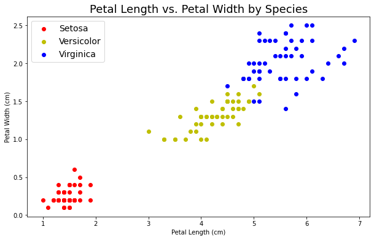

```python
# create 2 objects: fig and ax
fig, ax = plt.subplots(figsize=(10,6))

# separate the data by species into 3 new dataframe objects
setosa = df[df['species']==0]
versicolor = df[df['species']==1]
virginica = df[df['species']==2]

# call each Axes object's scatter method to plot the data
ax.scatter(setosa['petal length (cm)'],
            setosa['petal width (cm)'],
            c='r', label='Setosa')
ax.scatter(versicolor['petal length (cm)'],
            versicolor['petal width (cm)'],
            c='y', label='Versicolor')
ax.scatter(virginica['petal length (cm)'],
            virginica['petal width (cm)'],
            c='b', label='Virginica')

# add a legend to the plot using the legend() method of the Axes object
ax.legend(fontsize=14)

# add x and y axis labels and a title to the plot by calling more Axes object methods
ax.set_xlabel('Petal Length (cm)')
ax.set_ylabel('Petal Width (cm)')
ax.set_title('Petal Length vs. Petal Width by Species', fontsize=18)

# display the plot
plt.show()
```

## Predicting Flower Species from Petal Length and Width

From the plot we made above, it seems that flowers of the same species have similar petal sizes. For instance, the Iris Setosa flowers seem to have petals with smaller length and width. Based on this observation, we may wonder whether the species of a flower can be predicted given the length and width of its petals. Let's try!

First, let's drop the label (the variable we want to predict) from our dataframe using the drop method we saw before...

```python
X = df.drop('species', axis=1)
```

and store it separately:

```python
y = df['species']
```

Now let's split our iris data into training and testing data. The general purpose of each set is as follows:

- We will let our model try to "learn" the patterns and relationships that exist in the the training data.
- Then, we will evaluate our model's ability to predict the species of a flower by giving it data points it has not seen before from the test set.

NOTE: This is a simplified explanation of the role of training and testing sets. To learn more, click [here](https://www.javatpoint.com/train-and-test-datasets-in-machine-learning).

```python
X_train, X_test, y_train, y_test = train_test_split(X, y, test_size=0.2)
```

#### the K-Nearest Neighbors Algorithm

K-Nearest Neighbors (KNN) is an algorithm that predicts the label of new data based on the labels of its K nearest neighbors in the training data. The class with the majority of votes from these neighbors is assigned as the predicted label for the new instance.

For example, let's say you're using the k-nearest neighbors (k-NN) algorithm with k=3 and your training data is the entire Iris dataset. If I ask you to predict the species of a new flower with petal length of 1.5 cm and petal width of 0.5 cm, you will identify the 3 data points in your training data that are closest to this new point and predict the label of the new point as the label that appears most frequently from these 3 closest points. Based on the plot shown previously, the three closest points to (1.5, 0.5) are all of the species *Iris Setosa*. Therefore, the predicted label for the new flower is *Iris Setosa*!

#### Scikit-learn's Implementation of K-NN

```python
knn = KNeighborsClassifier(n_neighbors=3)
```

The `KNeighborsClassifier()` in scikit-learn is an object-oriented implementation of the k-nearest neighbors algorithm. Let's consider what makes the `KNeighborsClassifier()` a good example of object-oriented programming concepts:

- **Abstraction**: The `KNeighborsClassifier()` class abstracts away the k-nearest neighbors algorithm's details and allows us to fit data to our model, make predictions on new data, and evaluate the model without knowing anything about the class implementation. Thus, we as users understand what the class does, but we do not know how it does it.
- **Encapsulation**: The `KNeighborsClassifier()` class bundles the k-nearest neighbors algorithm's data and methods into a single object, and provides a clean interface for interacting with the model.

```python
# fit the classifier to the training data
knn.fit(X_train, y_train);
```

```python
# evaluate the accuracy of the classifier
accuracy = knn.score(X_test, y_test)
print(f"Accuracy: {accuracy}")
```

```
Accuracy: 0.9666666666666667
```

#### Extending scikit-learn's KNeighborsClassifier()

The model we fit to the iris data above, `knn`, can predict the integer labels of new data values:

```python
# an example flower
example_flower = pd.DataFrame({
    'petal length (cm)': [1.5],
    'petal width (cm)': [0.5]
})

# predicting the flower species given the flower's petal length and width
knn.predict(example_flower)
```

```
array([0])
```

We can see our model predicts that our example flower has the label of 0. We know as the developers of this code that 0 corresponds with the species *Iris Setosa*; however, a user of our code may not know that. We may at times want our model's prediction to output the corresponding flower name and not output an integer. Let's write code to map integer labels to species names to make it easier for users to interpret the model's predictions!

While we could write a function to map integer labels to species names, an OOP approach could be more useful for predicting the names of species as it provides a more organized and modular approach, allowing for easier modifications and extensions of the code we write. Let's extend scikit-learn's `KNeighborsClassifier()` using inheritence!

```python
class MyKNeighborsClassifier(KNeighborsClassifier):
    """
    A custom K-NN classifier for predicting Iris flowers based on their petals.
    Our class inherits from `KNeighborsClassifier` class in scikit-learn and adds
    a `predict_species` method that returns a list of predicted species names instead
    of integer labels.
    """
    def __init__(self, k=5, weights='uniform', algorithm='auto', **kwargs):
        super().__init__(n_neighbors=k, weights=weights, algorithm=algorithm, **kwargs)

        # a dictionary attrribute that maps integer predictions to species names
        self.map = {
            0: 'Iris Setosa',
            1: 'Iris Versicolor',
            2: 'Iris Virginica'
        }

    def __label_to_species(self, prediction):
        """Private method that maps integer prediction labels to species names"""
        # make sure the prediction is an integer between 0 and 2 (inclusive)
        assert isinstance(prediction, np.integer)
        assert 0 <= prediction and prediction <= 2

        # return the corresponding species name for the label
        return self.map[prediction]


    def get_species_names(self, labels):
        """Public method that converts integer labels to species names"""
        assert isinstance(labels, np.ndarray) or isinstance(labels, pd.Series)
        # convert our integer predictions to species names using the map dictionary
        species = []
        for label in labels:
            species_name = self.__label_to_species(label)
            species.append(species_name)

        # return species names
        return species

    def predict_species(self, X):
        """Public method to predict the species names of each row in X"""
        # use K-NN's predict method to get integer predictions
        predictions = super().predict(X)
        return self.get_species_names(predictions)
```

We can now fit our training data to our new subclass:

```python
my_knn = MyKNeighborsClassifier(k=3)
my_knn.fit(X_train, y_train);
```

And predict the species based on the flower petal length and width:

```python
my_knn.predict_species(example_flower)
```

```
['Iris Setosa']
```

## Conclusion

Through exploring a small data science problem and considering our choices as we went, we learned how object-oriented programming (OOP) concepts are relevant to data science. In particular, we used the Iris dataset, represented it using the pandas DataFrame class, and visualized the relationship between petal size and the flower's species using matplotlib. We then explored object-oriented programming concepts by using scikit-learn's `KNeighborsClassifier()` to predict the species of flowers given petal length and width.

Understanding OOP as data scientists enables us to use libraries more effectively and build better models. I hope that this example helped to illustrate how relevant OOP is in data science.